# A2_Walburger_Riley

Riley Walburger

2024-10-04

## Load Data and Libraries

```r
knitr::opts_chunk$set(echo = TRUE)

library(tidyverse)
library(psych)
library(RWeka)
library(dplyr)
library(purrr)
library(readr)
library(ggplot2)
library(gridExtra)
library(grid)
library(rpart)
library(rpart.plot)
library(caret)
library(C50)
library(rminer)
library(rmarkdown)
library(tictoc)
```

```r
CD_additional_balanced_1 <- read_csv("C:/Users/walbr/Desktop/U of U/1- Fall Semester 2024/Data Mining/Assignment 2 - Decision Tree/CD_additional_balanced-1.csv")
#head(CD_additional_balanced_1)

CD_factor <- CD_additional_balanced_1 %>%
  mutate(across(c(job, marital, education, default, housing, loan, contact, month, day_of_week, poutcome, y), as.factor))

head(CD_factor)
```

```
## # A tibble: 6 × 21
##     age job    marital education default housing loan  contact month day_of_week
##   <dbl> <fct>  <fct>   <fct>     <fct>   <fct>   <fct> <fct>   <fct> <fct>
## 1    41 blue-… divorc… basic.4y  unknown yes     no    teleph… may   mon
## 2    49 entre… married universi… unknown yes     no    teleph… may   mon
## 3    49 techn… married basic.9y  no      no      no    teleph… may   mon
## 4    41 techn… married professi… unknown yes     no    teleph… may   mon
## 5    45 blue-… married basic.9y  unknown yes     no    teleph… may   mon
## 6    42 blue-… married basic.9y  no      yes     yes   teleph… may   mon
## # ℹ 11 more variables: duration <dbl>, campaign <dbl>, pdays <dbl>,
## #   previous <dbl>, poutcome <fct>, emp.var.rate <dbl>, cons.price.idx <dbl>,
## #   cons.conf.idx <dbl>, euribor3m <dbl>, nr.employed <dbl>, y <fct>
```

Now that we have loaded the data and can see the format of the data, we can now begin diving into what it looks like.

## Target Variable

The target variable is y which stands for yes or no to the question: Did the client subscribe to a certified term deposit(CD).

```r
CD_factor %>% pull(y) %>% table()
```

```
## .
##   no  yes
## 4640 4640
```

```r
CD_factor %>% pull(y) %>% table() %>% prop.table() %>% round(2)
```

```
## .
##  no yes
## 0.5 0.5
```

There are exactly the same number of yes as no responses in this dataset. Which means that before any models you can randomly select anyone in this dataset and have a 50% chance of having them say yes to subscribing to a CD.

## Data Preparation

### Splitting the Data

Next we are going to partition the data in order to test and train a model on this target variable.

```r
set.seed(10)  # Setting seed for reproducibility

# Split the data: 70% train, 30% test
trainIndex <- createDataPartition(CD_factor$y, p = 0.7,
                                  list = FALSE)

trainData <- CD_factor[trainIndex, ]  # 70% training data
testData  <- CD_factor[-trainIndex, ] # 30% test data
```

I have first set a seed so that it can be reproducable and then allowed the computer to split the CD data into 70% training data and 30% testing data. This way we can make sure that after we create the model we can use it on the testing data(data that the model has never seen before) and make sure that it can still be accurate.

### Train vs Test Data

Lets now take a look at the Training and testing data to see what each set of data looks like after splitting them.

#### Training Data

```r
CD_factor %>% pull(y) %>% table()
```

```
## .
##   no  yes
## 4640 4640
```

```r
CD_factor %>% pull(y) %>% table() %>% prop.table() %>% round(2)
```

```
## .
##  no yes
## 0.5 0.5
```

```r
summary(trainData)
```

```
##       age                 job           marital                   education
##  Min.   :17.00   admin.     :1746   divorced: 704   university.degree  :2076
##  1st Qu.:31.00   blue-collar:1237   married :3737   high.school        :1493
##  Median :38.00   technician :1048   single  :2039   professional.course: 843
##  Mean   :40.36   services   : 524   unknown :  16   basic.9y           : 837
##  3rd Qu.:48.00   management : 448                   basic.4y           : 606
##  Max.   :98.00   retired    : 403                   basic.6y           : 328
##                  (Other)    :1090                   (Other)            : 313
##     default        housing          loan           contact         month
##  no     :5493   no     :2843   no     :5393   cellular :4668   may    :1753
##  unknown:1003   unknown: 153   unknown: 153   telephone:1828   jul    :1028
##                 yes    :3500   yes    : 950                    aug    : 945
##                                                                jun    : 830
##                                                                nov    : 642
##                                                                apr    : 555
##                                                                (Other): 743
##  day_of_week    duration         campaign          pdays          previous
##  fri:1262    Min.   :   1.0   Min.   : 1.000   Min.   :  0.0   Min.   :0.000
##  mon:1290    1st Qu.: 145.8   1st Qu.: 1.000   1st Qu.:999.0   1st Qu.:0.000
##  thu:1377    Median : 265.0   Median : 2.000   Median :999.0   Median :0.000
##  tue:1256    Mean   : 387.2   Mean   : 2.344   Mean   :884.8   Mean   :0.324
##  wed:1311    3rd Qu.: 528.0   3rd Qu.: 3.000   3rd Qu.:999.0   3rd Qu.:0.000
##              Max.   :4199.0   Max.   :39.000   Max.   :999.0   Max.   :6.000
##
##         poutcome     emp.var.rate     cons.price.idx  cons.conf.idx
##  failure    : 769   Min.   :-3.4000   Min.   :92.20   Min.   :-50.80
##  nonexistent:5042   1st Qu.:-1.8000   1st Qu.:92.89   1st Qu.:-42.70
##  success    : 685   Median :-0.1000   Median :93.44   Median :-41.80
##                     Mean   :-0.4974   Mean   :93.48   Mean   :-40.27
##                     3rd Qu.: 1.4000   3rd Qu.:93.99   3rd Qu.:-36.40
##                     Max.   : 1.4000   Max.   :94.77   Max.   :-26.90
##
##    euribor3m      nr.employed     y
##  Min.   :0.634   Min.   :4964   no :3248
##  1st Qu.:1.244   1st Qu.:5076   yes:3248
##  Median :4.021   Median :5191
##  Mean   :2.962   Mean   :5135
##  3rd Qu.:4.959   3rd Qu.:5228
##  Max.   :5.045   Max.   :5228
##
```

#### Test Data

```r
CD_factor %>% pull(y) %>% table()
```

```
## .
##   no  yes
## 4640 4640
```

```r
CD_factor %>% pull(y) %>% table() %>% prop.table() %>% round(2)
```

```
## .
##  no yes
## 0.5 0.5
```

```r
summary(testData)
```

```
##       age                job          marital                   education
##  Min.   :18.0   admin.     :771   divorced: 317   university.degree  :931
##  1st Qu.:31.0   blue-collar:532   married :1601   high.school        :609
##  Median :38.0   technician :411   single  : 861   professional.course:347
##  Mean   :40.5   services   :249   unknown :   5   basic.9y           :340
##  3rd Qu.:48.0   management :203                   basic.4y           :289
##  Max.   :92.0   retired    :192                   unknown            :137
##                 (Other)    :426                   (Other)            :131
##     default        housing          loan           contact         month
##  no     :2331   no     :1261   no     :2295   cellular :2004   may    :780
##  unknown: 453   unknown:  72   unknown:  72   telephone: 780   jul    :449
##                 yes    :1451   yes    : 417                    aug    :408
##                                                                jun    :339
##                                                                nov    :244
##                                                                apr    :230
##                                                                (Other):334
##  day_of_week    duration         campaign          pdays          previous
##  fri:501     Min.   :   6.0   Min.   : 1.000   Min.   :  0.0   Min.   :0.0000
##  mon:556     1st Qu.: 143.0   1st Qu.: 1.000   1st Qu.:999.0   1st Qu.:0.0000
##  thu:623     Median : 265.0   Median : 2.000   Median :999.0   Median :0.0000
##  tue:554     Mean   : 387.7   Mean   : 2.307   Mean   :893.1   Mean   :0.2949
##  wed:550     3rd Qu.: 526.2   3rd Qu.: 3.000   3rd Qu.:999.0   3rd Qu.:0.0000
##              Max.   :3643.0   Max.   :26.000   Max.   :999.0   Max.   :5.0000
##
##         poutcome     emp.var.rate     cons.price.idx  cons.conf.idx
##  failure    : 305   Min.   :-3.4000   Min.   :92.20   Min.   :-50.8
##  nonexistent:2202   1st Qu.:-1.8000   1st Qu.:92.89   1st Qu.:-42.7
##  success    : 277   Median :-0.1000   Median :93.44   Median :-41.8
##                     Mean   :-0.4936   Mean   :93.48   Mean   :-40.1
##                     3rd Qu.: 1.4000   3rd Qu.:93.99   3rd Qu.:-36.4
##                     Max.   : 1.4000   Max.   :94.77   Max.   :-26.9
##
##    euribor3m      nr.employed     y
##  Min.   :0.634   Min.   :4964   no :1392
##  1st Qu.:1.244   1st Qu.:5076   yes:1392
##  Median :4.021   Median :5191
##  Mean   :2.955   Mean   :5135
##  3rd Qu.:4.959   3rd Qu.:5228
##  Max.   :5.000   Max.   :5228
##
```

As we can see each data set is still perfectly half and half based on yes and no responses. That will be very simple for this test. This means that as long as we can predict better than a 50% chance we have gotten information gain.

## Training Decision Trees (All 7)

```r
# Create the model
CD_model1 <- C5.0(formula = y ~ ., data = trainData, earlyStopping = FALSE, noGlobalPruning = FALSE, control = C5.0Control(CF = 0.97))

CD_model2 <- C5.0(formula = y ~ ., data = trainData, earlyStopping = FALSE, noGlobalPruning = FALSE, control = C5.0Control(CF = 0.35))

CD_model3 <- C5.0(formula = y ~ ., data = trainData, earlyStopping = FALSE, noGlobalPruning = FALSE, control = C5.0Control(CF = 0.12))

CD_model4 <- C5.0(formula = y ~ ., data = trainData, earlyStopping = FALSE, noGlobalPruning = FALSE, control = C5.0Control(CF = 0.08))

CD_model5 <- C5.0(formula = y ~ ., data = trainData, earlyStopping = FALSE, noGlobalPruning = FALSE, control = C5.0Control(CF = 0.04))

CD_model6 <- C5.0(formula = y ~ ., data = trainData, earlyStopping = FALSE, noGlobalPruning = FALSE, control = C5.0Control(CF = 0.025))

CD_model7 <- C5.0(formula = y ~ ., data = trainData, earlyStopping = FALSE, noGlobalPruning = FALSE, control = C5.0Control(CF = 0.001))


CD_model7
```

```
##
## Call:
## C5.0.formula(formula = y ~ ., data = trainData, earlyStopping =
##  FALSE, noGlobalPruning = FALSE, control = C5.0Control(CF = 0.001))
##
## Classification Tree
## Number of samples: 6496
## Number of predictors: 20
##
## Tree size: 9
##
## Non-standard options: attempt to group attributes, confidence level: 0.001
```

In order to get a low tree size we have to have a very low confidence factor. We went with 0.001 to get under ten leaf nodes.

## Model Information

In the order they were built and order of confidence level you can see below the model leaf sizes.

```r
leaf_nodes_vector <- c(
  CD_model1$size,
  CD_model2$size,
  CD_model3$size,
  CD_model4$size,
  CD_model5$size,
  CD_model6$size,
  CD_model7$size)

leaf_nodes_vector
```

```
## [1] 292 103  50  39  27  27   9
```

The most complex trees go really deep and splits the data into 292 groups. The least complex tree is the last one with only 9 leaf nodes.

Below I will show the least complex one created to show how this is working.

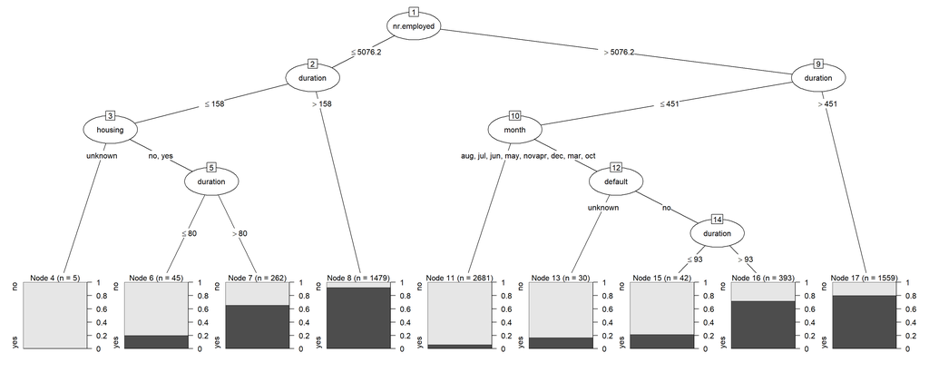

```r
# Plot the model
plot(CD_model7)
```

The plot shown above starts at the top and works its way down with each decision. So the very first decision is if the variable nr.employed is greater than 5076.2 and depending on the answer to that question it will go down each way of the tree. So for example if for one row of data nr.employed = 6000 and duration = 500 then that instance it would go right on the first one based on 6000 > 5076.2 and then go right again because 500 > 451 on duration landing this instance in the far right bucket which seems to be an 80% chance of being a yes in our target variable.

## Predict and Test

The first thing we are doing in this section is using our models to create predictions. We are doing this twice for each model. Once on the training dataset and once on the test dataset. This will help us to see at what point we are starting to over fit our model.

```r
CD_model1_Predictions_Train <- predict(CD_model1, trainData)
CD_model1_Predictions_Test <- predict(CD_model1, testData)

CD_model2_Predictions_Train <- predict(CD_model2, trainData)
CD_model2_Predictions_Test <- predict(CD_model2, testData)

CD_model3_Predictions_Train <- predict(CD_model3, trainData)
CD_model3_Predictions_Test <- predict(CD_model3, testData)

CD_model4_Predictions_Train <- predict(CD_model4, trainData)
CD_model4_Predictions_Test <- predict(CD_model4, testData)

CD_model5_Predictions_Train <- predict(CD_model5, trainData)
CD_model5_Predictions_Test <- predict(CD_model5, testData)

CD_model6_Predictions_Train <- predict(CD_model6, trainData)
CD_model6_Predictions_Test <- predict(CD_model6, testData)

CD_model7_Predictions_Train <- predict(CD_model7, trainData)
CD_model7_Predictions_Test <- predict(CD_model7, testData)
```

Now that we have our predictions we will use them to see how accurate each model was on the training and test datasets.

```r
 metrics=c("F1","ACC","PRECISION","RECALL")

cf_vector <- c(0.97, 0.35, 0.12, 0.08, 0.04, 0.025, 0.001)
```

### Confusion Matrix

Though harder to read the confusion matrices give us the results of all models both test and train for you to look through. However the most understandable parts of what we are really getting from this is below in the grah and table of accuracies.

```r
mmetric(trainData$y, CD_model1_Predictions_Train, metric="CONF")
```

```
## $res
## NULL
##
## $conf
##       pred
## target   no  yes
##    no  2984  264
##    yes  148 3100
##
## $roc
## NULL
##
## $lift
## NULL
```

```r
mmetric(testData$y, CD_model1_Predictions_Test, metric="CONF")
```

```
## $res
## NULL
##
## $conf
##       pred
## target   no  yes
##    no  1189  203
##    yes  160 1232
##
## $roc
## NULL
##
## $lift
## NULL
```

```r
mmetric(trainData$y, CD_model2_Predictions_Train, metric="CONF")
```

```
## $res
## NULL
##
## $conf
##       pred
## target   no  yes
##    no  2834  414
##    yes  174 3074
##
## $roc
## NULL
##
## $lift
## NULL
```

```r
mmetric(testData$y, CD_model2_Predictions_Test, metric="CONF")
```

```
## $res
## NULL
##
## $conf
##       pred
## target   no  yes
##    no  1169  223
##    yes  113 1279
##
## $roc
## NULL
##
## $lift
## NULL
```

```r
mmetric(trainData$y, CD_model3_Predictions_Train, metric="CONF")
```

```
## $res
## NULL
##
## $conf
##       pred
## target   no  yes
##    no  2749  499
##    yes  174 3074
##
## $roc
## NULL
##
## $lift
## NULL
```

```r
mmetric(testData$y, CD_model3_Predictions_Test, metric="CONF")
```

```
## $res
## NULL
##
## $conf
##       pred
## target   no  yes
##    no  1163  229
##    yes   90 1302
##
## $roc
## NULL
##
## $lift
## NULL
```

```r
mmetric(trainData$y, CD_model4_Predictions_Train, metric="CONF")
```

```
## $res
## NULL
##
## $conf
##       pred
## target   no  yes
##    no  2759  489
##    yes  213 3035
##
## $roc
## NULL
##
## $lift
## NULL
```

```r
mmetric(testData$y, CD_model4_Predictions_Test, metric="CONF")
```

```
## $res
## NULL
##
## $conf
##       pred
## target   no  yes
##    no  1174  218
##    yes  110 1282
##
## $roc
## NULL
##
## $lift
## NULL
```

```r
mmetric(trainData$y, CD_model5_Predictions_Train, metric="CONF")
```

```
## $res
## NULL
##
## $conf
##       pred
## target   no  yes
##    no  2706  542
##    yes  194 3054
##
## $roc
## NULL
##
## $lift
## NULL
```

```r
mmetric(testData$y, CD_model5_Predictions_Test, metric="CONF")
```

```
## $res
## NULL
##
## $conf
##       pred
## target   no  yes
##    no  1156  236
##    yes   98 1294
##
## $roc
## NULL
##
## $lift
## NULL
```

```r
mmetric(trainData$y, CD_model6_Predictions_Train, metric="CONF")
```

```
## $res
## NULL
##
## $conf
##       pred
## target   no  yes
##    no  2706  542
##    yes  194 3054
##
## $roc
## NULL
##
## $lift
## NULL
```

```r
mmetric(testData$y, CD_model6_Predictions_Test, metric="CONF")
```

```
## $res
## NULL
##
## $conf
##       pred
## target   no  yes
##    no  1156  236
##    yes   98 1294
##
## $roc
## NULL
##
## $lift
## NULL
```

```r
mmetric(trainData$y, CD_model7_Predictions_Train, metric="CONF")
```

```
## $res
## NULL
##
## $conf
##       pred
## target   no  yes
##    no  2617  631
##    yes  186 3062
##
## $roc
## NULL
##
## $lift
## NULL
```

```r
mmetric(testData$y, CD_model7_Predictions_Test, metric="CONF")
```

```
## $res
## NULL
##
## $conf
##       pred
## target   no  yes
##    no  1122  270
##    yes   87 1305
##
## $roc
## NULL
##
## $lift
## NULL
```

### Accuracy

```r
train_acc <- c(
  mmetric(trainData$y, CD_model1_Predictions_Train, metric="ACC"),
  mmetric(trainData$y, CD_model2_Predictions_Train, metric="ACC"),
  mmetric(trainData$y, CD_model3_Predictions_Train, metric="ACC"),
  mmetric(trainData$y, CD_model4_Predictions_Train, metric="ACC"),
  mmetric(trainData$y, CD_model5_Predictions_Train, metric="ACC"),
  mmetric(trainData$y, CD_model6_Predictions_Train, metric="ACC"),
  mmetric(trainData$y, CD_model7_Predictions_Train, metric="ACC")
)

test_acc <- c(
  mmetric(testData$y, CD_model1_Predictions_Test, metric="ACC"),
  mmetric(testData$y, CD_model2_Predictions_Test, metric="ACC"),
  mmetric(testData$y, CD_model3_Predictions_Test, metric="ACC"),
  mmetric(testData$y, CD_model4_Predictions_Test, metric="ACC"),
  mmetric(testData$y, CD_model5_Predictions_Test, metric="ACC"),
  mmetric(testData$y, CD_model6_Predictions_Test, metric="ACC"),
  mmetric(testData$y, CD_model7_Predictions_Test, metric="ACC")
)


acc_df_cf <- data.frame(train_acc,test_acc,cf_vector,leaf_nodes_vector)
acc_df_cf
```

```
##   train_acc test_acc cf_vector leaf_nodes_vector
## 1  93.65764 86.96121     0.970               292
## 2  90.94828 87.93103     0.350               103
## 3  89.63978 88.54167     0.120                50
## 4  89.19335 88.21839     0.080                39
## 5  88.66995 88.00287     0.040                27
## 6  88.66995 88.00287     0.025                27
## 7  87.42303 87.17672     0.001                 9
```

## Feature Importance

```r
C5imp(CD_model1)
```

```
##                Overall
## duration        100.00
## nr.employed     100.00
## month            53.57
## pdays            49.65
## day_of_week      41.12
## emp.var.rate     38.07
## poutcome         33.74
## euribor3m        24.85
## job              18.78
## cons.price.idx   18.33
## campaign         12.53
## contact          10.48
## education         9.16
## default           8.22
## housing           6.85
## loan              5.87
## cons.conf.idx     5.70
## marital           4.19
## previous          2.31
## age               1.83
```

```r
C5imp(CD_model2)
```

```
##                Overall
## duration        100.00
## nr.employed     100.00
## month            52.12
## pdays            49.65
## emp.var.rate     38.07
## euribor3m        24.60
## cons.price.idx   10.51
## contact          10.48
## day_of_week      10.41
## default           8.22
## cons.conf.idx     5.70
## housing           5.59
## campaign          4.25
## marital           3.05
## previous          2.96
## education         1.86
## age               1.77
## job               1.77
## loan              1.34
## poutcome          0.89
```

```r
C5imp(CD_model3)
```

```
##                Overall
## duration        100.00
## nr.employed     100.00
## month            50.88
## pdays            49.65
## emp.var.rate     46.91
## euribor3m        16.46
## contact          11.87
## cons.price.idx   10.51
## default           7.16
## cons.conf.idx     5.70
## day_of_week       5.62
## housing           4.80
## campaign          4.17
## previous          2.96
## marital           1.49
## age               1.20
## job               0.92
## loan              0.82
## education         0.00
## poutcome          0.00
```

```r
C5imp(CD_model4)
```

```
##                Overall
## duration        100.00
## nr.employed     100.00
## month            50.88
## pdays            49.97
## cons.price.idx   10.51
## emp.var.rate      6.40
## cons.conf.idx     6.05
## campaign          5.06
## housing           4.80
## euribor3m         4.43
## day_of_week       4.05
## previous          3.02
## age               1.37
## job               1.09
## loan              0.88
## marital           0.77
## education         0.00
## default           0.00
## contact           0.00
## poutcome          0.00
```

```r
C5imp(CD_model5)
```

```
##                Overall
## duration        100.00
## nr.employed     100.00
## pdays            49.97
## month            48.43
## emp.var.rate      6.40
## cons.conf.idx     6.05
## day_of_week       5.30
## euribor3m         5.23
## housing           4.80
## campaign          3.51
## age               1.57
## previous          1.34
## job               1.09
## marital           0.00
## education         0.00
## default           0.00
## loan              0.00
## contact           0.00
## poutcome          0.00
## cons.price.idx    0.00
```

```r
C5imp(CD_model6)
```

```
##                Overall
## duration        100.00
## nr.employed     100.00
## pdays            49.97
## month            48.43
## emp.var.rate      6.40
## cons.conf.idx     6.05
## day_of_week       5.30
## euribor3m         5.23
## housing           4.80
## campaign          3.51
## age               1.57
## previous          1.34
## job               1.09
## marital           0.00
## education         0.00
## default           0.00
## loan              0.00
## contact           0.00
## poutcome          0.00
## cons.price.idx    0.00
```

```r
C5imp(CD_model7)
```

```
##                Overall
## duration        100.00
## nr.employed     100.00
## month            48.43
## default           7.16
## housing           4.80
## age               0.00
## job               0.00
## marital           0.00
## education         0.00
## loan              0.00
## contact           0.00
## day_of_week       0.00
## campaign          0.00
## pdays             0.00
## previous          0.00
## poutcome          0.00
## emp.var.rate      0.00
## cons.price.idx    0.00
## cons.conf.idx     0.00
## euribor3m         0.00
```

The top 4 features were duration, nr.employed, month and pdays in all except one model. The bottom 2 attributes were often poutcome and education. In some of the more intense models that seem to be slightly over fitting the data these could become important.

## Train vs Test Accuracy

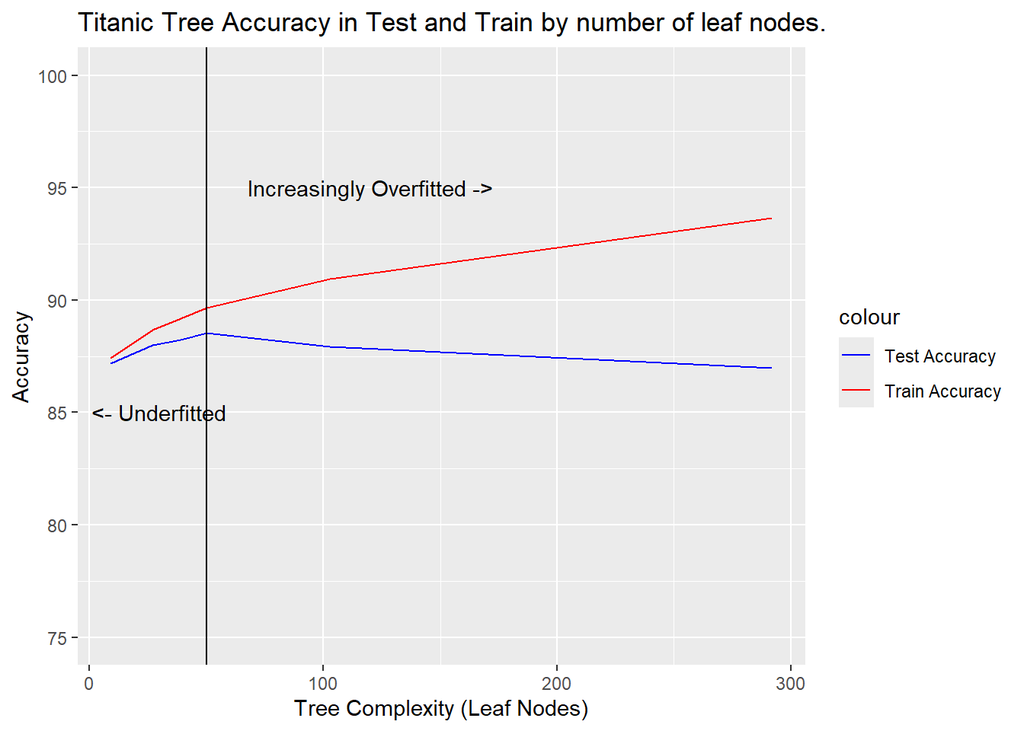

```r
ggplot() +
  geom_line(aes(x=acc_df_cf$leaf_nodes_vector,y=acc_df_cf$train_acc,color='Train Accuracy')) +
  geom_line(aes(x=acc_df_cf$leaf_nodes_vector,y=acc_df_cf$test_acc,color='Test Accuracy')) +
  scale_color_manual(values = c("Train Accuracy" = "red", "Test Accuracy" = "blue")) +
  ggtitle("Titanic Tree Accuracy in Test and Train by number of leaf nodes.") +
  xlab('Tree Complexity (Leaf Nodes)') +
  ylab('Accuracy') +
  ylim(75,100) +
  geom_vline(xintercept = 50) +
  geom_text(aes(x=30,y=85),label='<- Underfitted') +
  geom_text(aes(x=120,y=95),label='Increasingly Overfitted ->')
```

As we can see in the models made above we can overfit the data we have and thus reduce our accuracy in Test or live data. This is why we have to be careful with our CF.

The best model on the train data was the most complex model with a CF of .97. It had 292 leaf nodes and made a ton of decisions based on the data.

Our best performing model had a CF of .12 and had 50 leaf nodes. Its training accuracy was about 89% with others being into the 90s. However it had the highest test accuracy out of all of them which is more important.

I think that the Train test score is much less important to the Test accuracy. The train gets us a good idea that the model is working however the test is where we make sure that we aren’t going to far and ruining the model with data outside of the what we are training the model on.

In conclusion because everything under about 50 leaf nodes is underfitted and everything over that seems to be overfitted to the data the model I would choose is the one with a CF of .12. It is the one that can predict the very best on live data.